# Recommender System

This note will review recommender systems that are categorized as collaborative filtering. The recommenderlab package offers an efficient set of functions to implement these recommenders. recommenderlab is implemented using formal classes in the S4 class system. For details, see Hahsler (2018) https://cran.r-project.org/web/packages/recommenderlab/vignettes/recommenderlab.pdf. This package was updated recently, so even if you have installed it before, it is best to reinstall it.

```r
# install.packages('recommenderlab')
library(recommenderlab)
```

## 1 Read Data

Use a dataset of jokes that comes with recommenderlab package. The data set contains a sample of 5000 users from the anonymous ratings data from the Jester Online Joke Recommender System collected between April 1999 and May 2003.

```r
data(Jester5k)
```

Here is one of the jokes.

```r
JesterJokes[[48]]
```

```
## [1] "The graduate with a Science degree asks, \"Why does it work?\" The graduate with an Engineering degree asks, \"How does it work?\" The graduate with an Accounting degree Asks, \"How much will it cost?\" The graduate with a Liberal Arts degree asks, \"Do you want fries with that?\""
```

Data is stored as a realRatingMatrix

```r
Jester5k
```

```
## 5000 x 100 rating matrix of class 'realRatingMatrix' with 362106 ratings.
```

User-item matrices are often sparse. Some users rate more than others and some items get rated more than others but few or no items are rated by all and few or no users rate everything. Thus, the user-item matrix contains a number of missing values. Jester5k is a sparse matrix with only 72% elements rated.

```r
nratings(Jester5k)/(ncol(Jester5k)*nrow(Jester5k))
```

```
## [1] 0.724212
```

Using a realRatingMatrix makes a number of recommenderlab functions accessible.

```r
methods(class = 'realRatingMatrix')
```

```
##  [1] [                      [<-                    binarize
##  [4] calcPredictionAccuracy coerce                 colCounts
##  [7] colMeans               colSds                 colSums
## [10] denormalize            dim                    dimnames
## [13] dimnames<-             dissimilarity          evaluationScheme
## [16] getData.frame          getList                getNormalize
## [19] getRatingMatrix        getRatings             getTopNLists
## [22] hasRating              image                  normalize
## [25] nratings               Recommender            removeKnownRatings
## [28] rowCounts              rowMeans               rowSds
## [31] rowSums                sample                 show
## [34] similarity
## see '?methods' for accessing help and source code
```

and also a number of recommender models

```r
names(recommenderRegistry$get_entries(dataType='realRatingMatrix'))
```

```
##  [1] "HYBRID_realRatingMatrix"       "ALS_realRatingMatrix"
##  [3] "ALS_implicit_realRatingMatrix" "IBCF_realRatingMatrix"
##  [5] "LIBMF_realRatingMatrix"        "POPULAR_realRatingMatrix"
##  [7] "RANDOM_realRatingMatrix"       "RERECOMMEND_realRatingMatrix"
##  [9] "SVD_realRatingMatrix"          "SVDF_realRatingMatrix"
## [11] "UBCF_realRatingMatrix"
```

## 2 Get Familiar with the Data and Structure

```r
Jester5k
```

```
## 5000 x 100 rating matrix of class 'realRatingMatrix' with 362106 ratings.
```

Dimensions of this realRatingMatrix

```r
dim(Jester5k)
```

```
## [1] 5000  100
```

structure of the object

```r
str(Jester5k)
```

```
## Formal class 'realRatingMatrix' [package "recommenderlab"] with 2 slots
##   ..@ data     :Formal class 'dgCMatrix' [package "Matrix"] with 6 slots
##   .. .. ..@ i       : int [1:362106] 0 1 2 3 4 5 6 7 8 9 ...
##   .. .. ..@ p       : int [1:101] 0 3314 6962 10300 13442 18440 22513 27512 32512 35685 ...
##   .. .. ..@ Dim     : int [1:2] 5000 100
##   .. .. ..@ Dimnames:List of 2
##   .. .. .. ..$ : chr [1:5000] "u2841" "u15547" "u15221" "u15573" ...
##   .. .. .. ..$ : chr [1:100] "j1" "j2" "j3" "j4" ...
##   .. .. ..@ x       : num [1:362106] 7.91 -3.2 -1.7 -7.38 0.1 0.83 2.91 -2.77 -3.35 -1.99 ...
##   .. .. ..@ factors : list()
##   ..@ normalize: NULL
```

Implementation of image by recommenderlab generates a heatmap.

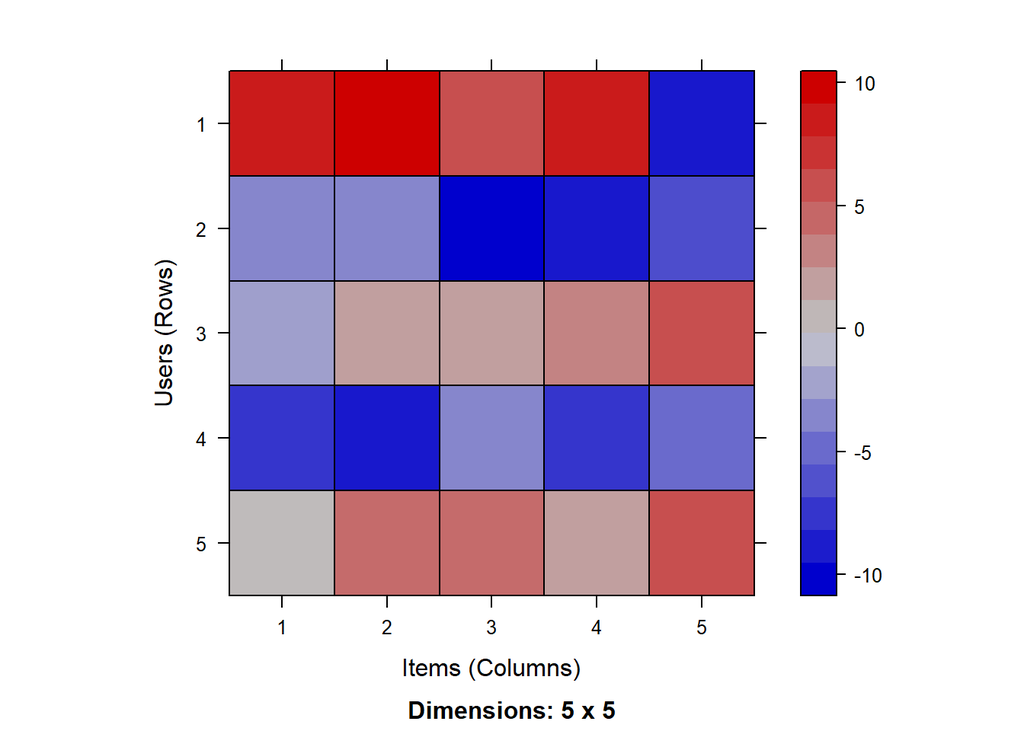

```r
image(Jester5k[1:5,1:5])
```

To view the raw data, we transform it to a matrix form. You will note that a realRatingMatrix places users along rows and items along columns.

```r
as(Jester5k,'matrix')[1:5, 1:5]
```

```
##           j1    j2    j3    j4    j5
## u2841   7.91  9.17  5.34  8.16 -8.74
## u15547 -3.20 -3.50 -9.56 -8.74 -6.36
## u15221 -1.70  1.21  1.55  2.77  5.58
## u15573 -7.38 -8.93 -3.88 -7.23 -4.90
## u21505  0.10  4.17  4.90  1.55  5.53
```

Another alternative for viewing raw data is to use the getRatingMatrix from recommenderlab

```r
getRatingMatrix(Jester5k)[1:5,1:5]
```

```
## 5 x 5 sparse Matrix of class "dgCMatrix"
##           j1    j2    j3    j4    j5
## u2841   7.91  9.17  5.34  8.16 -8.74
## u15547 -3.20 -3.50 -9.56 -8.74 -6.36
## u15221 -1.70  1.21  1.55  2.77  5.58
## u15573 -7.38 -8.93 -3.88 -7.23 -4.90
## u21505  0.10  4.17  4.90  1.55  5.53
```

Let us extract rating of Jokes 56 to 60 by u7676. Once data is converted to a matrix format, traditional methods for subsetting a matrix can be employed.

```r
as(Jester5k,'matrix')['u7676',c('j56','j57','j58','j59','j60')]
```

```
##  j56  j57  j58  j59  j60
## 5.34   NA   NA   NA 4.22
```

From the foregoing lines of code, it must be obvious that we can extract data by applying recommenderlab functions to a realRatingMatrix or convert the latter to matrix and then apply traditional functions. Let us answer the following questions using each method.

Q: How many jokes did u7676 rate?

A: Using recommenderlab functions

```r
nratings(Jester5k['u7676'])
```

```
## [1] 60
```

A: Using traditional ways

```r
sum(!is.na(as(Jester5k,'matrix')['u7676',]))
```

```
## [1] 60
```

Q: What was the mean rating of jokes by u7676?

A: Using recommenderlab functions

```r
mean(getRatings(Jester5k['u7676']))
```

```
## [1] 3.476
```

A: Using traditional ways

```r
mean(as(Jester5k,'matrix')['u7676',],na.rm=T)
```

```
## [1] 3.476
```

You will note that the realRatingMatrix is not a tidy format. Here is what the data would look like in a tidy format. Shown below is the head of a tidy dataset.

```r
library(tidyr); library(tibble)
data.frame(as(Jester5k,'matrix'))%>%
  rownames_to_column(var = 'user')%>%
  gather(key = 'joke',value = rating,2:101)%>%
  head()
```

|  | user | joke | rating |
| --- | --- | --- | --- |
| 1 | u2841 | j1 | 7.91 |
| 2 | u15547 | j1 | -3.20 |
| 3 | u15221 | j1 | -1.70 |
| 4 | u15573 | j1 | -7.38 |
| 5 | u21505 | j1 | 0.10 |
| 6 | u15994 | j1 | 0.83 |

## 3 Split Data

Split the dataset, retaining 80% in the train sample

```r
set.seed(617)
split = sample(x = nrow(Jester5k),size = 0.8*nrow(Jester5k))
train = Jester5k[split,]
test = Jester5k[-split,]
```

## 4 Explore Train data

Let us examine the number of jokes rated by users. What can you say about the number of jokes rated by each user and the number of jokes rated by most users?

```r
summary(rowCounts(train))
```

```
##    Min. 1st Qu.  Median    Mean 3rd Qu.    Max.
##   36.00   53.75   72.00   72.48  100.00  100.00
```

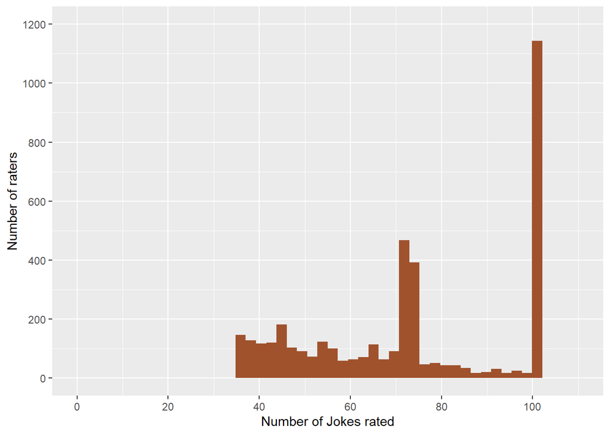

```r
library(ggplot2)
ggplot(data=data.frame(no_of_jokes_rated = rowCounts(train)),aes(x=no_of_jokes_rated))+
  geom_histogram(bins=50,fill='sienna')+ylab('Number of raters')+xlab('Number of Jokes rated')+
  scale_x_continuous(breaks = seq(0,100,20),limits=c(0,110))+
  scale_y_continuous(breaks=seq(0,1200,200),limits=c(0,1200))
```

Now, let us examine the number of ratings jokes received. What can you say about the number of ratings each jokes received? Did all jokes get rated the same number of times?

```r
summary(colCounts(train))
```

```
##    Min. 1st Qu.  Median    Mean 3rd Qu.    Max.
##    1373    1634    3199    2899    3964    4000
```

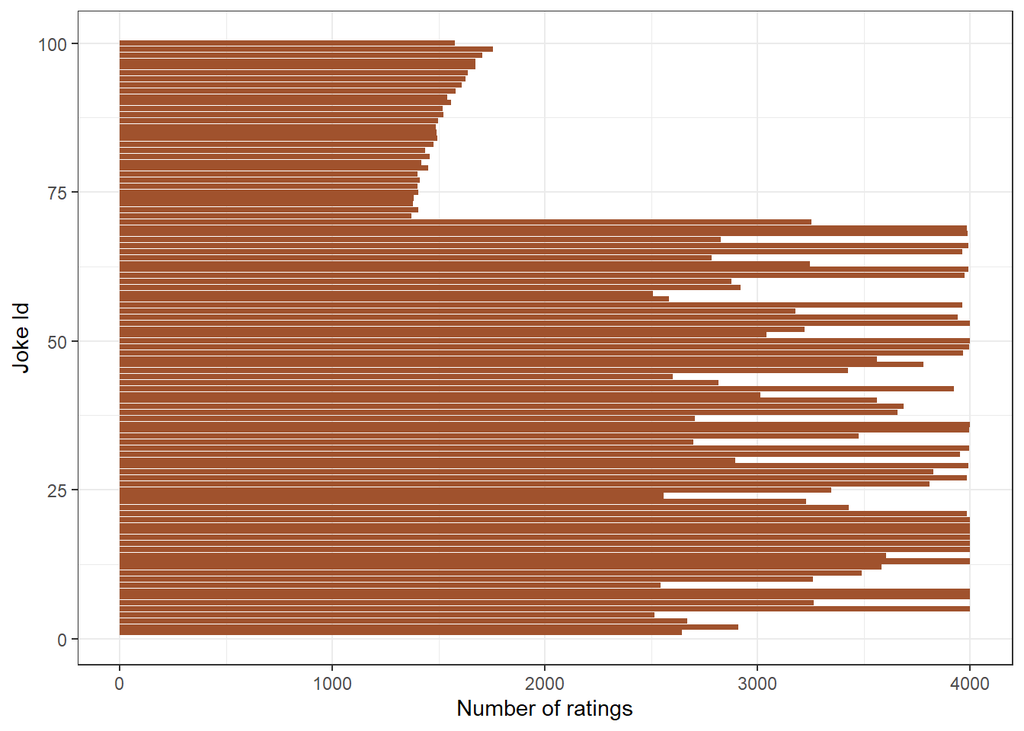

```r
library(tidyr);library(tibble); library(ggthemes)
data.frame(no_of_ratings=colCounts(train))%>%
  rownames_to_column()%>%
  ggplot(aes(x=as.numeric(gsub(rowname,pattern = '[a-z]',replacement = '')), y=no_of_ratings))+
  geom_col(fill='sienna')+xlab('Joke Id')+ylab('Number of ratings')+coord_flip()+ theme_bw()
```

Let us examine the average rating of the first six Jokes

```r
head(colMeans(train))
```

```
##         j1         j2         j3         j4         j5         j6
##  0.9440469  0.2282680  0.2021386 -1.5022554  0.3858890  1.6987688
```

Let us examine the distribution of average ratings of the 100 Jokes. Are some jokes rated better than others? Are ratings of jokes skewed to the high end of the scale?

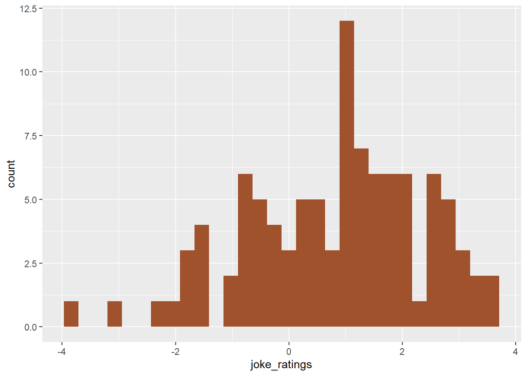

```r
library(ggplot2)
ggplot(data=data.frame(joke_ratings = colMeans(train)),aes(x=joke_ratings))+
  geom_histogram(fill='sienna')
```

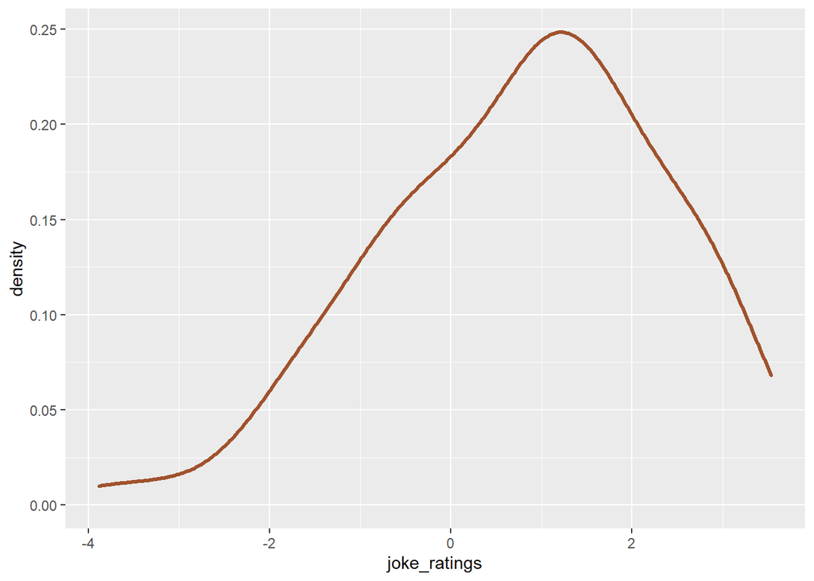

```r
ggplot(data=data.frame(joke_ratings = colMeans(train)),aes(x=joke_ratings))+
  geom_density(color='sienna', size=1.2)
```

Let us examine the average rating of the first six users

```r
head(rowMeans(train))
```

```
##      u5092     u14163     u22876       u195     u16903       u245
## -2.4134286  1.3239583  4.9240278 -2.7950000  3.4979167  0.5396491
```

Let us examine the distribution of jokes ratings by 4000 users in the train sample. Do users consistently rate jokes positively or negatively?

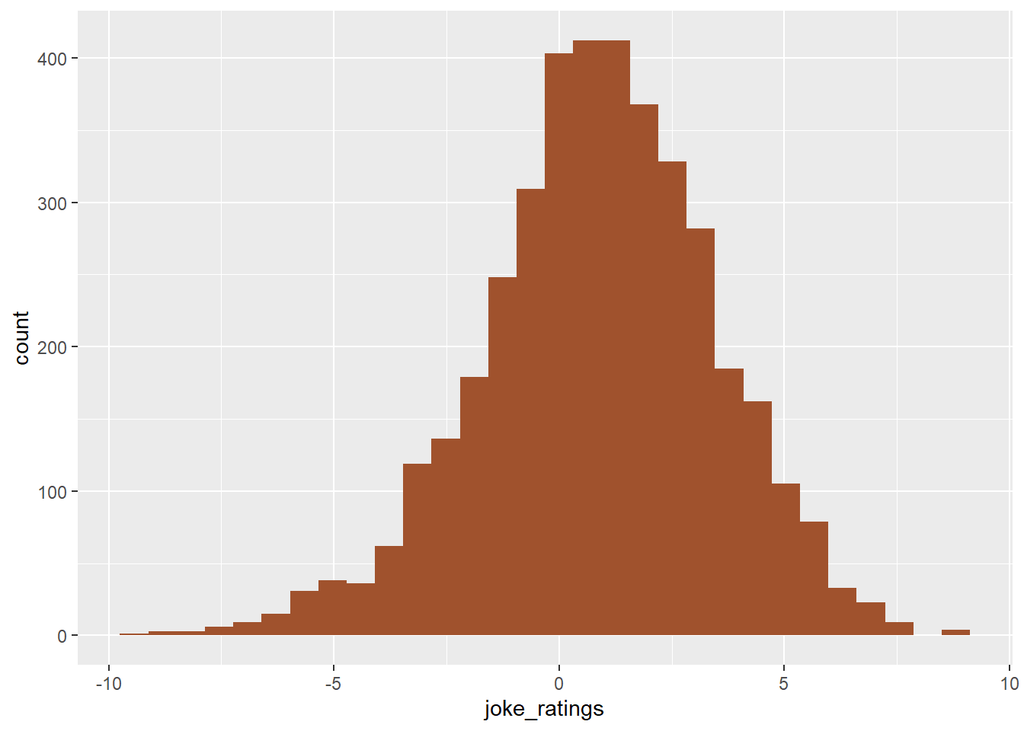

```r
library(ggplot2)
ggplot(data=data.frame(joke_ratings = rowMeans(train)),aes(x=joke_ratings))+
  geom_histogram(fill='sienna')
```

## 5 Prepare Data

-*Normalization (centering)*  
People tend to differ in their ratings styles. For instance, some will rate few items (e.g., jokes) highly while others will rate most items highly. To control for individual differences, it is common to normalize the data by either centering (center) it or standardizing it (Z-score).

Let us examine the effect of centering on the ratings of u7676. Data before centering.

```r
getRatings(train['u7676'])
```

```
##  [1]  4.66  5.05  4.95  1.31  4.61  2.57  0.63  4.42  5.29  5.44  0.19  2.52
## [13] -1.80  0.78 -1.26  2.62 -0.68  1.80  4.17  4.08  5.05  5.29  2.09  2.77
## [25]  3.11  4.76  6.26  6.46  4.76  2.43  2.72  3.06  0.92  2.28  6.26  8.69
## [37]  4.56  4.95  5.10  2.28  4.37  1.26  6.36  3.11  2.67  3.74  7.23  2.28
## [49]  5.34  4.22  2.14  1.12  3.98  5.05  6.50  4.47  5.83  2.72 -0.19  1.21
```

```r
summary(getRatings(train['u7676']))
```

```
##    Min. 1st Qu.  Median    Mean 3rd Qu.    Max.
##  -1.800   2.245   3.860   3.476   5.050   8.690
```

Data after centering.

```r
getRatings(normalize(train, method='center')['u7676'])
```

```
##  [1]  1.184  1.574  1.474 -2.166  1.134 -0.906 -2.846  0.944  1.814  1.964
## [11] -3.286 -0.956 -5.276 -2.696 -4.736 -0.856 -4.156 -1.676  0.694  0.604
## [21]  1.574  1.814 -1.386 -0.706 -0.366  1.284  2.784  2.984  1.284 -1.046
## [31] -0.756 -0.416 -2.556 -1.196  2.784  5.214  1.084  1.474  1.624 -1.196
## [41]  0.894 -2.216  2.884 -0.366 -0.806  0.264  3.754 -1.196  1.864  0.744
## [51] -1.336 -2.356  0.504  1.574  3.024  0.994  2.354 -0.756 -3.666 -2.266
```

```r
summary(getRatings(normalize(train, method='center')['u7676']))
```

```
##    Min. 1st Qu.  Median    Mean 3rd Qu.    Max.
##  -5.276  -1.231   0.384   0.000   1.574   5.214
```

Summary of ratings for all users after centering.

```r
summary(rowMeans(normalize(train,method='center')))
```

```
##       Min.    1st Qu.     Median       Mean    3rd Qu.       Max.
## -4.505e-15 -2.822e-16  0.000e+00  9.028e-18  2.822e-16  6.193e-15
```

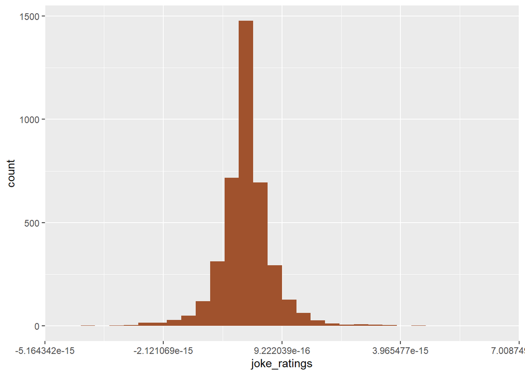

```r
ggplot(data=data.frame(joke_ratings = rowMeans(normalize(train))),aes(x=joke_ratings))+
  geom_histogram(fill='sienna')
```

Now, let us examine the effect of centering on ratings of j50. Rating of j50 for first 25 users before centering.

```r
getRatings(train[1:25,'j50'])
```

```
##  [1]  2.96  6.41  9.22  1.80  7.28  0.73 -3.93  3.35  0.68  4.42  1.02  6.12
## [13]  4.42  4.76  6.50  9.13  7.04  4.71 -2.18  9.08  8.79  2.96  8.45  1.65
## [25]  5.44
```

Rating of j50 for first 25 users after centering.

```r
getRatings(normalize(train)[1:25,'j50'])
```

```
##  [1]  5.3734286  5.0860417  4.2959722  4.5950000  3.7820833  0.1903509
##  [7] -6.0808451  4.1358000  3.3042857  0.7572973  1.0349000  1.1707000
## [13]  6.8935135  4.4711268  5.5832000  7.7457778  5.3176389  4.8777632
## [19] -6.5945833  9.8675000  9.7074468  5.7832432  8.0625352  1.9634524
## [25]  1.3727778
```

From the above, you may have noted that we generally only normalize user data not item data.

```r
summary(getRatings(normalize(train)[,'j50']))
```

```
##     Min.  1st Qu.   Median     Mean  3rd Qu.     Max.
## -14.8441   0.7144   2.9783   2.6754   5.1323  14.2604
```

Finally, one could go one step ahead of centering by standardizing the data (i.e., center and express in standard deviation units). Data before standardizing

```r
getRatings(train['u7676'])
```

```
##  [1]  4.66  5.05  4.95  1.31  4.61  2.57  0.63  4.42  5.29  5.44  0.19  2.52
## [13] -1.80  0.78 -1.26  2.62 -0.68  1.80  4.17  4.08  5.05  5.29  2.09  2.77
## [25]  3.11  4.76  6.26  6.46  4.76  2.43  2.72  3.06  0.92  2.28  6.26  8.69
## [37]  4.56  4.95  5.10  2.28  4.37  1.26  6.36  3.11  2.67  3.74  7.23  2.28
## [49]  5.34  4.22  2.14  1.12  3.98  5.05  6.50  4.47  5.83  2.72 -0.19  1.21
```

```r
summary(getRatings(train['u7676']))
```

```
##    Min. 1st Qu.  Median    Mean 3rd Qu.    Max.
##  -1.800   2.245   3.860   3.476   5.050   8.690
```

Data after standardizing.

```r
getRatings(normalize(train, method='Z-score')['u7676'])
```

```
##  [1]  0.5438467  0.7229854  0.6770524 -0.9949087  0.5208802 -0.4161529
##  [7] -1.3072531  0.4336075  0.8332246  0.9021240 -1.5093583 -0.4391194
## [13] -2.4234249 -1.2383536 -2.1753867 -0.3931864 -1.9089753 -0.7698370
## [19]  0.3187750  0.2774353  0.7229854  0.8332246 -0.6366313 -0.3242870
## [25] -0.1681148  0.5897797  1.2787746  1.3706406  0.5897797 -0.4804591
## [31] -0.3472535 -0.1910813 -1.1740474 -0.5493586  1.2787746  2.3949464
## [37]  0.4979137  0.6770524  0.7459519 -0.5493586  0.4106410 -1.0178752
## [43]  1.3247076 -0.1681148 -0.3702199  0.1212631  1.7243247 -0.5493586
## [49]  0.8561910  0.3417415 -0.6136648 -1.0821814  0.2315023  0.7229854
## [55]  1.3890138  0.4565740  1.0812627 -0.3472535 -1.6839036 -1.0408417
```

```r
summary(getRatings(normalize(train, method='Z-score')['u7676']))
```

```
##    Min. 1st Qu.  Median    Mean 3rd Qu.    Max.
## -2.4234 -0.5654  0.1764  0.0000  0.7230  2.3949
```

## 6 Similarity

Let us examine cosine similarity among the first five users. Library recommenderlab comes with a function, similarity() that can be used to compute euclidean distance, cosine similarity, and pearson correlation. The three methods vary in the extent to which they standardize similarity.

```r
similarity(normalize(train)[1:5],method = 'euclidean')
```

```
##             u5092     u14163     u22876       u195
## u14163 0.02051023
## u22876 0.01830506 0.01804014
## u195   0.01944195 0.01667579 0.01357619
## u16903 0.01884840 0.01605939 0.01575788 0.01337091
```

```r
similarity(normalize(train)[1:5],method = 'cosine')
```

```
##               u5092       u14163       u22876         u195
## u14163  0.004226426
## u22876  0.181413039  0.221160094
## u195    0.168586227  0.005961224 -0.172707678
## u16903  0.109864977 -0.045638098  0.216789387 -0.189342144
```

```r
similarity(normalize(train)[1:5],method = 'pearson')
```

```
##            u5092    u14163    u22876      u195
## u14163 0.5010599
## u22876 0.5498844 0.5622133
## u195   0.5460327 0.5014963 0.5000000
## u16903 0.5290751 0.5000000 0.5606983 0.5000000
```

recommenderlab functions perform normalizing and compute similarity measures within the Recommender function, so in practice there is no need to perform these functions earlier.

## 7 Construct Recommendations

### 7.1 Non-Personalized Recommendations: Popular

One of the oldest approaches to recommendations involves recommending the most popular item. Although less widely used today, we still see this in the form of Top 50 Music Hits, Billboard Top Hits, and New York Times Bestsellers. The underlying assumption is that if most people like a movie, a book or a song, you will like it too.

Let us examine the POPULAR method that implements this technique

```r
recommenderRegistry$get_entries(dataType='realRatingMatrix')$POPULAR_realRatingMatrix
```

```
## Recommender method: POPULAR for realRatingMatrix
## Description: Recommender based on item popularity.
## Reference: NA
## Parameters:
##   normalize
## 1  "center"
##                                                      aggregationRatings
## 1 new("standardGeneric", .Data = function (x, na.rm = FALSE, dims = 1,
##                                                   aggregationPopularity
## 1 new("standardGeneric", .Data = function (x, na.rm = FALSE, dims = 1,
```

We implement the POPULAR method using the Recommend function. We pass it a parameter to normalize train data using the center method (although, center is the default)

```r
recom_popular = Recommender(train,
                            method='POPULAR',
                            parameter=list(normalize='center'))
```

#### 7.1.1 Top n recommendations

Use the Recommender object to generate Top 5 predictions for the test sample. Note, topNList is the default type.

```r
pred_popular_topN = predict(recom_popular,newdata=test,type='topNList',n=5)
```

Top 5 joke recommendations for the first ten users in the test sample

```r
getList(pred_popular_topN)[1:10]
```

```
## $u238
## [1] "j53" "j49" "j61" "j42" "j11"
##
## $u6662
## character(0)
##
## $u7556
## character(0)
##
## $u6617
## character(0)
##
## $u7602
## [1] "j89" "j72" "j93" "j76" "j91"
##
## $u4519
## [1] "j89" "j72" "j91" "j83" "j88"
##
## $u13802
## [1] "j89" "j72" "j93" "j76" "j91"
##
## $u7778
## [1] "j89" "j11" "j6"  "j72" "j93"
##
## $u12519
## [1] "j89" "j72" "j93" "j76" "j91"
##
## $u6083
## character(0)
```

Let’s see the top 5 joke recommendations for u7602

```r
getList(pred_popular_topN)['u7602']
```

```
## $u7602
## [1] "j89" "j72" "j93" "j76" "j91"
```

#### 7.1.2 Ratings

Now, instead of generating the Top n recommendations for each user, we can also generate ratings for each joke. To do this, we use the type, ‘ratings’ instead of ‘topNList’

```r
pred_popular = predict(recom_popular,newdata=test,type='ratings')
```

Jokes rated by u7602

```r
as(test,'matrix')['u7602',]
```

```
##    j1    j2    j3    j4    j5    j6    j7    j8    j9   j10   j11   j12   j13
##    NA  9.22 -9.56    NA  7.28 -9.22  6.60 -7.77    NA  9.03 -2.86 -1.36 -7.77
##   j14   j15   j16   j17   j18   j19   j20   j21   j22   j23   j24   j25   j26
##  7.96  7.77 -8.83 -8.01 -8.59 -7.77  7.04  7.57 -9.27 -9.61    NA  8.11 -0.68
##   j27   j28   j29   j30   j31   j32   j33   j34   j35   j36   j37   j38   j39
## -5.29  9.17  8.16    NA -5.68  6.21    NA -0.68  6.84 -7.62    NA -4.08 -9.61
##   j40   j41   j42   j43   j44   j45   j46   j47   j48   j49   j50   j51   j52
##  2.72 -9.66 -9.22    NA    NA -9.56 -9.22  8.16  3.79 -4.61  6.75 -9.66  1.70
##   j53   j54   j55   j56   j57   j58   j59   j60   j61   j62   j63   j64   j65
## -6.94 -0.78    NA  0.24    NA    NA -6.99 -9.32 -9.47  3.64 -9.66    NA  0.10
##   j66   j67   j68   j69   j70   j71   j72   j73   j74   j75   j76   j77   j78
##  9.13    NA  9.03 -7.52 -9.71    NA    NA    NA    NA -6.60    NA    NA    NA
##   j79   j80   j81   j82   j83   j84   j85   j86   j87   j88   j89   j90   j91
##    NA    NA    NA    NA    NA    NA -6.80    NA    NA    NA    NA    NA    NA
##   j92   j93   j94   j95   j96   j97   j98   j99  j100
##    NA    NA    NA -8.40    NA    NA    NA    NA    NA
```

Predicted ratings for jokes not rated by u7602

```r
as(pred_popular,'matrix')['u7602',]
```

```
##          j1          j2          j3          j4          j5          j6
## -1.64723478          NA          NA -4.18169918          NA          NA
##          j7          j8          j9         j10         j11         j12
##          NA          NA -3.38636173          NA          NA          NA
##         j13         j14         j15         j16         j17         j18
##          NA          NA          NA          NA          NA          NA
##         j19         j20         j21         j22         j23         j24
##          NA          NA          NA          NA          NA -4.32852149
##         j25         j26         j27         j28         j29         j30
##          NA          NA          NA          NA          NA -3.21832398
##         j31         j32         j33         j34         j35         j36
##          NA          NA -4.16497024          NA          NA          NA
##         j37         j38         j39         j40         j41         j42
## -4.10681634          NA          NA          NA          NA          NA
##         j43         j44         j45         j46         j47         j48
## -3.54201000 -4.93186911          NA          NA          NA          NA
##         j49         j50         j51         j52         j53         j54
##          NA          NA          NA          NA          NA          NA
##         j55         j56         j57         j58         j59         j60
## -2.25327191          NA -4.81129545 -6.57366700          NA          NA
##         j61         j62         j63         j64         j65         j66
##          NA          NA          NA -3.36220570          NA          NA
##         j67         j68         j69         j70         j71         j72
## -3.54204936          NA          NA          NA -3.44314836 -0.02190592
##         j73         j74         j75         j76         j77         j78
## -1.78579297 -4.42473991          NA -0.38115821 -2.19652733 -1.28500649
##         j79         j80         j81         j82         j83         j84
## -2.85167662 -1.88882197 -1.13534402 -1.86123518 -0.85544917 -2.16243200
##         j85         j86         j87         j88         j89         j90
##          NA -2.67536436 -1.14943969 -0.91539768  0.60549796 -2.38261891
##         j91         j92         j93         j94         j95         j96
## -0.85502632 -1.63362176 -0.31209917 -1.97021469          NA -1.47030541
##         j97         j98         j99        j100
## -1.22914858 -2.02297399 -2.98789643 -1.57957444
```

```r
sort(as(pred_popular,'matrix')['u7602',],decreasing = T)
```

```
##         j89         j72         j93         j76         j91         j83
##  0.60549796 -0.02190592 -0.31209917 -0.38115821 -0.85502632 -0.85544917
##         j88         j81         j87         j97         j78         j96
## -0.91539768 -1.13534402 -1.14943969 -1.22914858 -1.28500649 -1.47030541
##        j100         j92          j1         j73         j82         j80
## -1.57957444 -1.63362176 -1.64723478 -1.78579297 -1.86123518 -1.88882197
##         j94         j98         j84         j77         j55         j90
## -1.97021469 -2.02297399 -2.16243200 -2.19652733 -2.25327191 -2.38261891
##         j86         j79         j99         j30         j64          j9
## -2.67536436 -2.85167662 -2.98789643 -3.21832398 -3.36220570 -3.38636173
##         j71         j43         j67         j37         j33          j4
## -3.44314836 -3.54201000 -3.54204936 -4.10681634 -4.16497024 -4.18169918
##         j24         j74         j57         j44         j58
## -4.32852149 -4.42473991 -4.81129545 -4.93186911 -6.57366700
```

```r
summary(as(test,'matrix')['u7602',])
```

```
##    Min. 1st Qu.  Median    Mean 3rd Qu.    Max.    NA's
##  -9.710  -8.710  -4.610  -1.901   6.675   9.220      41
```

Ratings for jokes 51-60 by users 55-60 in the test

```r
as(test,'matrix')[55:60,51:60]
```

```
##          j51   j52   j53   j54   j55   j56   j57   j58   j59   j60
## u19374    NA    NA  5.44  4.27  5.92  7.77    NA    NA    NA  8.06
## u18224 -9.85 -5.19  2.48  3.25 -2.23  0.24 -9.85  1.41 -6.70 -3.16
## u17195 -3.20 -2.62  5.10  8.88 -0.10  3.54 -8.40 -8.64 -1.50 -7.18
## u15028  1.31  6.17 -7.04  6.46 -2.28 -0.92 -5.78  0.97  3.20  2.96
## u7628     NA    NA  0.83  2.09    NA  2.96    NA -5.78    NA    NA
## u23430  3.74 -6.84  6.02 -9.08  7.38  3.11  4.95 -4.61 -7.57 -7.14
```

Predicted Ratings for jokes 51-60 by users 55-60 in the test

```r
as(pred_popular,'matrix')[55:60,51:60]
```

```
##              j51       j52 j53 j54        j55 j56        j57      j58       j59
## u19374  1.850405  2.551580  NA  NA         NA  NA  0.4542113 -1.30816  1.983546
## u18224        NA        NA  NA  NA         NA  NA         NA       NA        NA
## u17195        NA        NA  NA  NA         NA  NA         NA       NA        NA
## u15028        NA        NA  NA  NA         NA  NA         NA       NA        NA
## u7628  -1.904918 -1.203743  NA  NA -0.7430883  NA -3.3011118       NA -1.771777
## u23430        NA        NA  NA  NA         NA  NA         NA       NA        NA
##              j60
## u19374        NA
## u18224        NA
## u17195        NA
## u15028        NA
## u7628  -1.500422
## u23430        NA
```

### 7.2 User-based collaborative filtering

Examine parameters for UBCF

```r
recommenderRegistry$get_entries(data='realRatingMatrix')$UBCF_realRatingMatrix
```

```
## Recommender method: UBCF for realRatingMatrix
## Description: Recommender based on user-based collaborative filtering.
## Reference: NA
## Parameters:
##     method nn sample weighted normalize min_matching_items min_predictive_items
## 1 "cosine" 25  FALSE     TRUE  "center"                  0                    0
```

```r
recom_ubcf = Recommender(train, method='UBCF', parameter=list(method='cosine',
                                                              nn=25, normalize='center'))
```

#### 7.2.1 Top n recommendations

```r
pred_ubcf_topN = predict(recom_ubcf,newdata=test,method='topNList',n=5)
```

```r
getList(pred_ubcf_topN)[1:5]
```

```
## $u238
## [1] "j61"  "j12"  "j100" "j11"  "j34"
##
## $u6662
## character(0)
##
## $u7556
## character(0)
##
## $u6617
## character(0)
##
## $u7602
## [1] "j72" "j89" "j83" "j98" "j93"
```

```r
getList(pred_ubcf_topN)['u7602']
```

```
## $u7602
## [1] "j72" "j89" "j83" "j98" "j93"
```

```r
slotNames(pred_ubcf_topN)
```

```
## [1] "items"      "ratings"    "itemLabels" "n"
```

```r
pred_ubcf_topN@items['u7602']
```

```
## $u7602
## [1] 72 89 83 98 93
```

#### 7.2.2 Ratings

Now, instead of generating the Top n recommendations for each user, we can also generate ratings for each joke. To do this, we use the type, ‘ratings’ instead of ‘topNList’

```r
pred_ubcf = predict(recom_ubcf,newdata=test,type='ratings')
```

Jokes rated by u7602

```r
as(test,'matrix')['u7602',]
```

```
##    j1    j2    j3    j4    j5    j6    j7    j8    j9   j10   j11   j12   j13
##    NA  9.22 -9.56    NA  7.28 -9.22  6.60 -7.77    NA  9.03 -2.86 -1.36 -7.77
##   j14   j15   j16   j17   j18   j19   j20   j21   j22   j23   j24   j25   j26
##  7.96  7.77 -8.83 -8.01 -8.59 -7.77  7.04  7.57 -9.27 -9.61    NA  8.11 -0.68
##   j27   j28   j29   j30   j31   j32   j33   j34   j35   j36   j37   j38   j39
## -5.29  9.17  8.16    NA -5.68  6.21    NA -0.68  6.84 -7.62    NA -4.08 -9.61
##   j40   j41   j42   j43   j44   j45   j46   j47   j48   j49   j50   j51   j52
##  2.72 -9.66 -9.22    NA    NA -9.56 -9.22  8.16  3.79 -4.61  6.75 -9.66  1.70
##   j53   j54   j55   j56   j57   j58   j59   j60   j61   j62   j63   j64   j65
## -6.94 -0.78    NA  0.24    NA    NA -6.99 -9.32 -9.47  3.64 -9.66    NA  0.10
##   j66   j67   j68   j69   j70   j71   j72   j73   j74   j75   j76   j77   j78
##  9.13    NA  9.03 -7.52 -9.71    NA    NA    NA    NA -6.60    NA    NA    NA
##   j79   j80   j81   j82   j83   j84   j85   j86   j87   j88   j89   j90   j91
##    NA    NA    NA    NA    NA    NA -6.80    NA    NA    NA    NA    NA    NA
##   j92   j93   j94   j95   j96   j97   j98   j99  j100
##    NA    NA    NA -8.40    NA    NA    NA    NA    NA
```

Recommendations for Jokes not rated

```r
as(pred_ubcf,'matrix')['u7602',]
```

```
##         j1         j2         j3         j4         j5         j6         j7
##  0.4252532         NA         NA -4.0240540         NA         NA         NA
##         j8         j9        j10        j11        j12        j13        j14
##         NA -6.0664725         NA         NA         NA         NA         NA
##        j15        j16        j17        j18        j19        j20        j21
##         NA         NA         NA         NA         NA         NA         NA
##        j22        j23        j24        j25        j26        j27        j28
##         NA         NA -7.1110200         NA         NA         NA         NA
##        j29        j30        j31        j32        j33        j34        j35
##         NA -7.0806337         NA         NA -2.2160850         NA         NA
##        j36        j37        j38        j39        j40        j41        j42
##         NA -5.9338766         NA         NA         NA         NA         NA
##        j43        j44        j45        j46        j47        j48        j49
## -5.0117518 -7.0550270         NA         NA         NA         NA         NA
##        j50        j51        j52        j53        j54        j55        j56
##         NA         NA         NA         NA         NA -4.6272718         NA
##        j57        j58        j59        j60        j61        j62        j63
## -7.3055620 -7.7070706         NA         NA         NA         NA         NA
##        j64        j65        j66        j67        j68        j69        j70
## -4.7577581         NA         NA -6.0812369         NA         NA         NA
##        j71        j72        j73        j74        j75        j76        j77
## -1.8074904  2.1899084 -1.9344307 -5.4937182         NA -2.5589974 -3.0194354
##        j78        j79        j80        j81        j82        j83        j84
## -1.1072481 -4.1423077 -1.3538005  0.8341537 -0.6767704  1.4713462 -5.1126313
##        j85        j86        j87        j88        j89        j90        j91
##         NA -4.5480534 -1.4192413 -0.9956362  1.6231380 -2.4259397 -1.5079380
##        j92        j93        j94        j95        j96        j97        j98
## -1.7055887  1.1689603 -3.2716326         NA -4.0462800 -0.3282858  1.2396412
##        j99       j100
## -1.7344293  0.1999128
```

Ratings for jokes 51-60 by users 55-60 in the test

```r
as(test,'matrix')[55:60,51:60]
```

```
##          j51   j52   j53   j54   j55   j56   j57   j58   j59   j60
## u19374    NA    NA  5.44  4.27  5.92  7.77    NA    NA    NA  8.06
## u18224 -9.85 -5.19  2.48  3.25 -2.23  0.24 -9.85  1.41 -6.70 -3.16
## u17195 -3.20 -2.62  5.10  8.88 -0.10  3.54 -8.40 -8.64 -1.50 -7.18
## u15028  1.31  6.17 -7.04  6.46 -2.28 -0.92 -5.78  0.97  3.20  2.96
## u7628     NA    NA  0.83  2.09    NA  2.96    NA -5.78    NA    NA
## u23430  3.74 -6.84  6.02 -9.08  7.38  3.11  4.95 -4.61 -7.57 -7.14
```

Predicted Ratings for jokes 51-60 by users 55-60 in the test

```r
as(pred_ubcf,'matrix')[55:60,51:60]
```

```
##               j51       j52 j53 j54      j55 j56       j57      j58       j59
## u19374  2.5387996 4.4196047  NA  NA       NA  NA  3.313522 1.168495  3.835591
## u18224         NA        NA  NA  NA       NA  NA        NA       NA        NA
## u17195         NA        NA  NA  NA       NA  NA        NA       NA        NA
## u15028         NA        NA  NA  NA       NA  NA        NA       NA        NA
## u7628  -0.6526787 0.7085059  NA  NA -1.04053  NA -1.287465       NA -3.081738
## u23430         NA        NA  NA  NA       NA  NA        NA       NA        NA
##              j60
## u19374        NA
## u18224        NA
## u17195        NA
## u15028        NA
## u7628  -2.853737
## u23430        NA
```

### 7.3 Item-based collaborative filtering

```r
recommenderRegistry$get_entries(data='realRatingMatrix')$IBCF_realRatingMatrix # see parameters for IBCF
```

```
## Recommender method: IBCF for realRatingMatrix
## Description: Recommender based on item-based collaborative filtering.
## Reference: NA
## Parameters:
##    k   method normalize normalize_sim_matrix alpha na_as_zero
## 1 30 "Cosine"  "center"                FALSE   0.5      FALSE
```

```r
recom_ibcf = Recommender(train, method='IBCF', parameter=list(k=30, method='cosine',
                                                              normalize='center'))
recom_ibcf
```

```
## Recommender of type 'IBCF' for 'realRatingMatrix'
## learned using 4000 users.
```

#### 7.3.1 Top n recommendations

```r
pred_ibcf_topN = predict(recom_ibcf,newdata=test,type='topNList',n=5)
```

```r
getList(pred_ibcf_topN)[1:5]
```

```
## $u238
## [1] "j25"  "j52"  "j100" "j45"  "j11"
##
## $u6662
## character(0)
##
## $u7556
## character(0)
##
## $u6617
## character(0)
##
## $u7602
## [1] "j97" "j91" "j89" "j88" "j93"
```

```r
getList(pred_ibcf_topN)['u7602']
```

```
## $u7602
## [1] "j97" "j91" "j89" "j88" "j93"
```

#### 7.3.2 Ratings

```r
pred_ibcf = predict(recom_ibcf,newdata=test,type='ratings')
```

Jokes rated

```r
as(test,'matrix')['u7602',]
```

```
##    j1    j2    j3    j4    j5    j6    j7    j8    j9   j10   j11   j12   j13
##    NA  9.22 -9.56    NA  7.28 -9.22  6.60 -7.77    NA  9.03 -2.86 -1.36 -7.77
##   j14   j15   j16   j17   j18   j19   j20   j21   j22   j23   j24   j25   j26
##  7.96  7.77 -8.83 -8.01 -8.59 -7.77  7.04  7.57 -9.27 -9.61    NA  8.11 -0.68
##   j27   j28   j29   j30   j31   j32   j33   j34   j35   j36   j37   j38   j39
## -5.29  9.17  8.16    NA -5.68  6.21    NA -0.68  6.84 -7.62    NA -4.08 -9.61
##   j40   j41   j42   j43   j44   j45   j46   j47   j48   j49   j50   j51   j52
##  2.72 -9.66 -9.22    NA    NA -9.56 -9.22  8.16  3.79 -4.61  6.75 -9.66  1.70
##   j53   j54   j55   j56   j57   j58   j59   j60   j61   j62   j63   j64   j65
## -6.94 -0.78    NA  0.24    NA    NA -6.99 -9.32 -9.47  3.64 -9.66    NA  0.10
##   j66   j67   j68   j69   j70   j71   j72   j73   j74   j75   j76   j77   j78
##  9.13    NA  9.03 -7.52 -9.71    NA    NA    NA    NA -6.60    NA    NA    NA
##   j79   j80   j81   j82   j83   j84   j85   j86   j87   j88   j89   j90   j91
##    NA    NA    NA    NA    NA    NA -6.80    NA    NA    NA    NA    NA    NA
##   j92   j93   j94   j95   j96   j97   j98   j99  j100
##    NA    NA    NA -8.40    NA    NA    NA    NA    NA
```

Recommendations for Jokes not rated

```r
as(pred_ibcf,'matrix')['u7602',]
```

```
##         j1         j2         j3         j4         j5         j6         j7
## -1.2018367         NA         NA -4.2837760         NA         NA         NA
##         j8         j9        j10        j11        j12        j13        j14
##         NA -6.4862906         NA         NA         NA         NA         NA
##        j15        j16        j17        j18        j19        j20        j21
##         NA         NA         NA         NA         NA         NA         NA
##        j22        j23        j24        j25        j26        j27        j28
##         NA         NA -6.2239619         NA         NA         NA         NA
##        j29        j30        j31        j32        j33        j34        j35
##         NA -6.8038739         NA         NA -5.6159458         NA         NA
##        j36        j37        j38        j39        j40        j41        j42
##         NA -4.4365071         NA         NA         NA         NA         NA
##        j43        j44        j45        j46        j47        j48        j49
## -7.1514112 -5.1258272         NA         NA         NA         NA         NA
##        j50        j51        j52        j53        j54        j55        j56
##         NA         NA         NA         NA         NA -5.6733279         NA
##        j57        j58        j59        j60        j61        j62        j63
## -5.4207885 -5.0225761         NA         NA         NA         NA         NA
##        j64        j65        j66        j67        j68        j69        j70
## -6.1754690         NA         NA -6.7985650         NA         NA         NA
##        j71        j72        j73        j74        j75        j76        j77
## -2.1703178  0.4463620 -6.9194944 -4.2379636         NA  0.9519787 -3.9375637
##        j78        j79        j80        j81        j82        j83        j84
## -2.3680282 -5.4473974 -5.0196057 -0.5256426 -1.9485224  0.6247610 -2.4777716
##        j85        j86        j87        j88        j89        j90        j91
##         NA -5.1215795 -0.9135127  1.0597379  1.6344292 -0.8523732  1.8335773
##        j92        j93        j94        j95        j96        j97        j98
## -1.8944481  0.9721270 -6.1305959         NA -2.6063404  2.4407542 -0.8066422
##        j99       j100
## -5.4506372 -3.1873168
```

```r
as(test,'matrix')[55:60,51:60]
```

```
##          j51   j52   j53   j54   j55   j56   j57   j58   j59   j60
## u19374    NA    NA  5.44  4.27  5.92  7.77    NA    NA    NA  8.06
## u18224 -9.85 -5.19  2.48  3.25 -2.23  0.24 -9.85  1.41 -6.70 -3.16
## u17195 -3.20 -2.62  5.10  8.88 -0.10  3.54 -8.40 -8.64 -1.50 -7.18
## u15028  1.31  6.17 -7.04  6.46 -2.28 -0.92 -5.78  0.97  3.20  2.96
## u7628     NA    NA  0.83  2.09    NA  2.96    NA -5.78    NA    NA
## u23430  3.74 -6.84  6.02 -9.08  7.38  3.11  4.95 -4.61 -7.57 -7.14
```

```r
as(pred_ubcf,'matrix')[55:60,51:60]
```

```
##               j51       j52 j53 j54      j55 j56       j57      j58       j59
## u19374  2.5387996 4.4196047  NA  NA       NA  NA  3.313522 1.168495  3.835591
## u18224         NA        NA  NA  NA       NA  NA        NA       NA        NA
## u17195         NA        NA  NA  NA       NA  NA        NA       NA        NA
## u15028         NA        NA  NA  NA       NA  NA        NA       NA        NA
## u7628  -0.6526787 0.7085059  NA  NA -1.04053  NA -1.287465       NA -3.081738
## u23430         NA        NA  NA  NA       NA  NA        NA       NA        NA
##              j60
## u19374        NA
## u18224        NA
## u17195        NA
## u15028        NA
## u7628  -2.853737
## u23430        NA
```

## 8 Evaluation Scheme

### 8.1 Split: Train - Test

Recommenderlab package has some handy built-in functions to evaluate different recommender models. Here, we are going to create an evaluation scheme from Jester5k, not the train dataset. evaluationScheme() handles splits, k-fold cross validation and bootstrapping under the hood.

Let us begin with a 80:20 split. We will give the recommender algorithm 30 items from the test set and hold out the other items for computing the error. The number of items (‘given’) must be less than the minimum items rated by any user. For this dataset, the least number of jokes rated by any user is 36

```r
min(rowCounts(Jester5k))
```

```
## [1] 36
```

```r
set.seed(1031)
es = evaluationScheme(Jester5k,method='split',train=0.8, given=30)
```

Train set

```r
getData(es,'train')
```

```
## 4000 x 100 rating matrix of class 'realRatingMatrix' with 289668 ratings.
```

Test set with the items used to build the recommendations

```r
getData(es,'known')
```

```
## 1000 x 100 rating matrix of class 'realRatingMatrix' with 30000 ratings.
```

Test set with the items used to evaluate the recommendations

```r
getData(es,'unknown')
```

```
## 1000 x 100 rating matrix of class 'realRatingMatrix' with 42438 ratings.
```

Total number of ratings = train + known + unknown

```r
nratings(Jester5k) == nratings(getData(es,'train')) + nratings(getData(es,'known')) +
                      nratings(getData(es,'unknown'))
```

```
## [1] TRUE
```

Number of items used to generate recommendations; value of ‘given’

```r
rowCounts(getData(es,'known'))[1:20]
```

```
## u22827  u4519 u13802 u15509  u8225 u16885 u12094  u3815  u7905  u7986  u3552
##     30     30     30     30     30     30     30     30     30     30     30
##  u7472   u665  u7706 u14061  u8103  u5463  u7047  u7915 u15759
##     30     30     30     30     30     30     30     30     30
```

Remaining items being held out for computing error.

```r
rowCounts(getData(es,'unknown'))[1:20]
```

```
## u22827  u4519 u13802 u15509  u8225 u16885 u12094  u3815  u7905  u7986  u3552
##     43     50     41     42     70     70     42     57     70     70     63
##  u7472   u665  u7706 u14061  u8103  u5463  u7047  u7915 u15759
##     70     24     42     30     10      6     70     45     12
```

Build recommender

```r
recom_ubcf = Recommender(data = getData(es,'train'),
                         method='UBCF',
                         parameter = list(method='cosine',nn=25,normalize='center'))
```

Generate Predictions

```r
pred_ubcf = predict(recom_ubcf,newdata=getData(es,'known'), type='ratings')
```

Evaluate Predictions

```r
calcPredictionAccuracy(pred_ubcf,data = getData(es,'unknown'))
```

```
##      RMSE       MSE       MAE
##  4.544705 20.654345  3.565705
```

Next let us calculate prediction accuracy for an IBCF

```r
recommenderRegistry$get_entries(data='realRatingMatrix')$IBCF_realRatingMatrix
```

```
## Recommender method: IBCF for realRatingMatrix
## Description: Recommender based on item-based collaborative filtering.
## Reference: NA
## Parameters:
##    k   method normalize normalize_sim_matrix alpha na_as_zero
## 1 30 "Cosine"  "center"                FALSE   0.5      FALSE
```

```r
recom_ibcf = Recommender(data = getData(es,'train'),
                         method='IBCF',
                         parameter = list(method='cosine',k=30,normalize='center'))
pred_ibcf = predict(recom_ibcf,newdata=getData(es,'known'), type='ratings')
calcPredictionAccuracy(pred_ibcf,data = getData(es,'unknown'))
```

```
##      RMSE       MSE       MAE
##  4.341846 18.851624  3.342718
```

### 8.2 k-fold cross-validation

Next, let us use k-fold cross-validation, first, to evaluate just UBCF

```r
set.seed(1031)
es = evaluationScheme(Jester5k,method='cross-validation',k=10,given=30)
ev = evaluate(x = es,method='UBCF',parameter=list(method='cosine',nn=25), type='ratings')
```

```
## UBCF run fold/sample [model time/prediction time]
##   1  [0.03sec/2.25sec]
##   2  [0.04sec/2.4sec]
##   3  [0.02sec/2.24sec]
##   4  [0.03sec/2.26sec]
##   5  [0.03sec/2.43sec]
##   6  [0.03sec/2.24sec]
##   7  [0.04sec/2.3sec]
##   8  [0.03sec/2.28sec]
##   9  [0.03sec/2.44sec]
##   10  [0.01sec/2.23sec]
```

```r
avg(ev)
```

```
##          RMSE      MSE      MAE
## [1,] 4.561912 20.81313 3.573399
```

Use k-fold cross-validation to evaluate a set of recommenders

```r
recommender_algorithms = list(random = list(name='RANDOM'),
                              popular = list(name='POPULAR'),
                              ubcf = list(name='UBCF'),
                              ubcf_50 = list(name='UBCF',parameters=list(nn=50)),
                              ubcf_100 = list(name='UBCF',parameters=list(nn=100)),
                              ibcf = list(name='IBCF'),
                              ibcf_10 = list(name='IBCF', parameters=list(k=10)))
ev = evaluate(x = es,method=recommender_algorithms, type='ratings')
```

```
## RANDOM run fold/sample [model time/prediction time]
##   1  [0sec/0.03sec]
##   2  [0sec/0.01sec]
##   3  [0sec/0.01sec]
##   4  [0.02sec/0.01sec]
##   5  [0sec/0.01sec]
##   6  [0sec/0.03sec]
##   7  [0.02sec/0.01sec]
##   8  [0sec/0.01sec]
##   9  [0sec/0.03sec]
##   10  [0.02sec/0.01sec]
## POPULAR run fold/sample [model time/prediction time]
##   1  [0.18sec/0sec]
##   2  [0.04sec/0sec]
##   3  [0.03sec/0.02sec]
```

[output cut: 62 more lines]

```r
results = matrix(unlist(avg(ev)),ncol=3,byrow=TRUE)
colnames(results) = c('RMSE','MSE','MAE')
rownames(results) = c('random','popular','ubcf','ubcf_50','ubcf_100','ibcf','ibcf_10')
results
```

```
##              RMSE      MSE      MAE
## random   6.315695 39.88997 4.897584
## popular  4.410310 19.45274 3.494418
## ubcf     4.561912 20.81313 3.573399
## ubcf_50  4.394851 19.31646 3.454142
## ubcf_100 4.310734 18.58408 3.390582
## ibcf     4.333407 18.78179 3.333610
## ibcf_10  4.692304 22.02181 3.493000
```

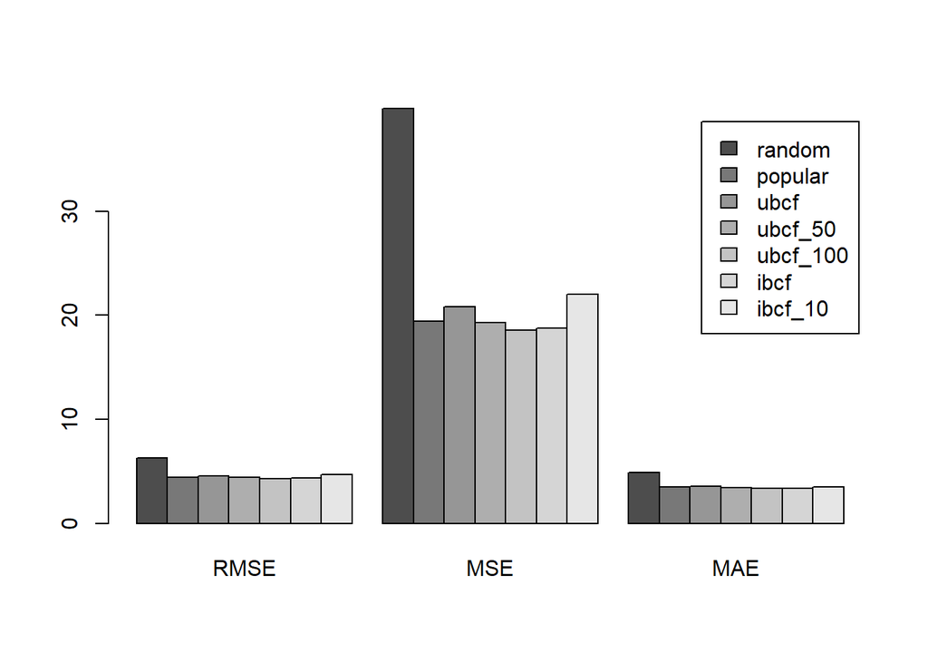

```r
plot(ev)
```

This file was generated using R Version 4.1.2